# Forschungspraktikum 1+2: Computational Social Science

Tutorial 09: Scraping Websites

Dr. Christian Czymara

Today, we will scrape data from websites. We will start with scraping data from Wikipedia and then move on to web scraping. We will scrape data from a conference website and from a website of your choice.

## 0. Getting Started

```r
packages <- c(
  "httr",         # HTTP requests
  "rvest",        # Web scraping
  "quanteda",     # Text analysis
  "dplyr",        # Data manipulation
  "ggplot2",      # Data visualization
  "lubridate"     # Date manipulation
  )

# install if necessary
install.packages(setdiff(packages, rownames(installed.packages())))

# load
lapply(packages, library, character.only = TRUE)
```

[output not shown]

## 1. Scraping Wikipedia

We want to scrape data from Wikipedia. In particular, we want to scrape information for Wikipedia’s page of Frankfurt. Check out the content of the page. We will first extract some information from the Wikipedia page and then scrape metadata from the API.

## a) Scraping Wikipedia Pages

To to scrape the Wikipedia page of Frankfurt, we need to access the page and extract the relevant information. Use the `read_html()` function of the `rvest` package to read the HTML content of the page.

```r
wiki_url <- "https://en.wikipedia.org/wiki/Frankfurt"

wiki_page <- read_html(wiki_url)
```

## b) Extracting Information

Now we can extract information from the Wikipedia page using CSS selectors. For example, we can extract all paragraphs of the page. Use the [SelectorGadget](https://chromewebstore.google.com/detail/selectorgadget/mhjhnkcfbdhnjickkkdbjoemdmbfginb) to identify the CSS selector for the paragraphs. Then use the `html_nodes()` function to select the elements and `html_text()` to extract the content.

```r
frankfurt_wiki_nodes <- html_nodes(wiki_page, "p")

frankfurt_wiki_text <- html_text(frankfurt_wiki_nodes)

head(frankfurt_wiki_text)
```

```
## [1] "\n\n"
## [2] "Frankfurt am Main (/ˈfræŋkfərt/; .mw-parser-output .IPA-label-small{font-size:85%}.mw-parser-output .references .IPA-label-small,.mw-parser-output .infobox .IPA-label-small,.mw-parser-output .navbox .IPA-label-small{font-size:100%}German: [ˈfʁaŋkfʊʁt ʔam ˈmaɪn] ⓘ;[5][6]lit. \"Frank ford on t…
## [3] "Frankfurt was a city state, the Free City of Frankfurt, for nearly five centuries, and was one of the most important cities of the Holy Roman Empire, as a site of Imperial coronations; it lost its sovereignty upon the collapse of the empire in 1806, regained it in 1815 and then lost it again…
## [4] "Frankfurt is a global hub for commerce, culture, education, tourism and transportation, and is the site of many global and European corporate headquarters. Due to its central location in the former West Germany, Frankfurt Airport became the busiest in Germany, one of the busiest in the world…
## [5] "Frankfurt is home to influential educational institutions, including the Goethe University with the Universitätsklinikum Frankfurt (de) (Hesse's largest hospital), the FUAS, the FUMPA, and graduate schools like the FSFM. The city is one of two seats of the German National Library (alongside …
## [6] "Frankfurt is the largest financial hub in continental Europe. It is home to the European Central Bank, Deutsche Bundesbank, Frankfurt Stock Exchange and several large commercial banks.\n"
```

## c) Scraping Tables

We can also scrape tables from the Wikipedia page. Based on the HTML content scraped in 1.a), scrape the table of the [largest foreign resident groups](https://en.wikipedia.org/wiki/Frankfurt#Demographics) in Frankfurt in 2022.

```r
# Solution 1: Scrape all tables, then extract the correct one (fifth)
wiki_foreign_table <- html_table(wiki_page)

wiki_foreign_table[[5]]
```

```
## # A tibble: 20 × 2
##    Nationality            `Population (30 June 2022)`
##    <chr>                  <chr>
##  1 Turkey                 25,294
##  2 Croatia                16,751
##  3 Italy                  15,120
##  4 Poland                 12,174
##  5 Romania                10,451
##  6 Ukraine                9,748
##  7 Serbia                 9,404
##  8 Bulgaria               8,509
##  9 India                  7,612
## 10 Morocco                7,364
## 11 Spain                  7,133
## 12 Greece                 6,581
## 13 Bosnia and Herzegovina 6,342
## 14 Afghanistan            5,114
## 15 France                 4,719
## 16 China                  4,632
## 17 Algeria                4,087
## 18 Portugal               3,991
## 19 Japan                  3,653
## 20 Eritrea                3,374
```

```r
# Solution 2: Directly scrape only the correct table
wiki_frankfurt_table_nodes <- html_nodes(wiki_page, ".table-pale+ .wikitable")

wiki_foreign_table <- html_table(wiki_frankfurt_table_nodes)

wiki_foreign_table
```

```
## [[1]]
## # A tibble: 20 × 2
##    Nationality            `Population (30 June 2022)`
##    <chr>                  <chr>
##  1 Turkey                 25,294
##  2 Croatia                16,751
##  3 Italy                  15,120
##  4 Poland                 12,174
##  5 Romania                10,451
##  6 Ukraine                9,748
##  7 Serbia                 9,404
##  8 Bulgaria               8,509
##  9 India                  7,612
## 10 Morocco                7,364
## 11 Spain                  7,133
## 12 Greece                 6,581
## 13 Bosnia and Herzegovina 6,342
## 14 Afghanistan            5,114
## 15 France                 4,719
## 16 China                  4,632
## 17 Algeria                4,087
## 18 Portugal               3,991
## 19 Japan                  3,653
## 20 Eritrea                3,374
```

# 2. Scraping Wikipedia Metadata

We can also scrape metadata from the [MediaWiki](https://www.mediawiki.org/wiki/API:Main_page) API. For example, we can scrape the daily page views of the Wikipedia page of Frankfurt between 01 Jan 2016 and today.

### a) Access the API

We use the `GET()` function from the `httr` package to access the API. The URL for the API request is `https://wikimedia.org/api/rest_v1/metrics/pageviews/per-article/en.wikipedia/all-access/all-agents/Frankfurt/daily/2016010100/2024121200`.

```r
wiki_url_02 <- GET("https://wikimedia.org/api/rest_v1/metrics/pageviews/per-article/en.wikipedia/all-access/all-agents/Frankfurt/daily/2016010100/2024121200")
```

### b) Extract Data

We can extract the data from the API response using the `content()` function. Use the `content()` function to `parse` the data. Then use `bind_rows()` to combine the parsed data into a data frame.

```r
wiki_meta_data <- content(wiki_url_02, "parsed")

wiki_meta_data <- bind_rows(wiki_meta_data$items)
```

### c) Prepare and Plot the Data

Convert the `timestamp` variable to a date format using `lubridate` (`ymd(substr(wiki_meta_data$timestamp, 1, nchar(wiki_meta_data$timestamp)-2))`) and plot the daily page views.

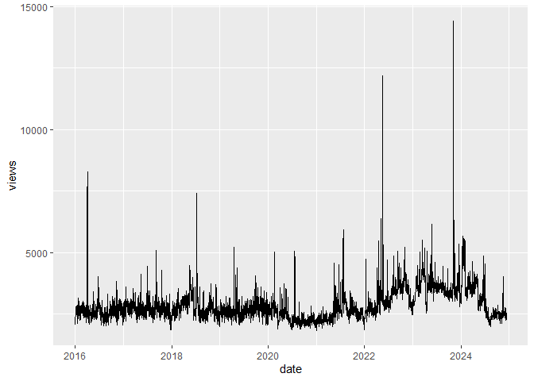

```r
wiki_meta_data$date <- ymd(substr(wiki_meta_data$timestamp, 1, nchar(wiki_meta_data$timestamp)-2))

# plot
wiki_meta_data %>%
  ggplot(aes(x = date,
             y = views)) +
  geom_line()
```

## 3. Scraping the IC2S2 Website

Next, we want to scrape information from the website of the [9th International Conference on Computational Social Science](https://ic2s2-2023.org/program). We will scrape the session titles and chairs.

### a) Inspect the Website

- Open the [ic2s2 website](https://ic2s2-2023.org/program) in a browser
- Use SelectorGadget to inspect the elements you want to scrape
- Identify the HTML tag and classes or IDs of the elements for:
  - The *session titles*
  - The *session chairs*

```r
# SelectorGadget: (only) session titles are .col-12-medium > h2
# SelectorGadget: (only) session chairs are h2 i
```

### b) Scrape the Website

Use `read_html()` to fetch the [IC2S2 program website](https://ic2s2-2023.org/program).

```r
ic2s2_url <- "https://ic2s2-2023.org/program"

ic2s2_page <- read_html(ic2s2_url)
```

### c) Parse and Extract Session Data

Use `html_nodes()` to select the elements identified in 3.a); then use `html_text()` to extract the text. Do this once for the session titles and once for the names of the session chairs.

```r
ic2s2_session_titles <- ic2s2_page %>%
  html_nodes(".col-12-medium > h2") %>%
  html_text()

ic2s2_session_chairs <- ic2s2_page %>%
  html_nodes("h2 i") %>%
  html_text()
```

### d) Combine Session Data

Combine the title and chair name data into one data frame. Who chaired more than one session at the conference?

```r
ic2s2_sessions <- data.frame(
  titles = ic2s2_session_titles,
  chairs = ic2s2_session_chairs)

head(ic2s2_sessions)
```

```
##                                                                                                                     titles
## 1      Session P1: "Plenary talks first session" - July 18, 9:45, Room A (Niels K. Jerne Auditorium) Chair: Claudia Wagner
## 2        Session P2: "Plenary talks second session" - July 19, 9:45, Room A (Niels K. Jerne Auditorium)Chair: Taha Yasseri
## 3                 Session 1A: "Polarization I" - July 18, 11:00, Room A (Niels K. Jerne Auditorium) [↑]Chair: David Garcia
## 4       Session 1B: "Social networks I" - July 18, 11:00 , Room B (Einar Lundsgaard Auditorium) [↑]Chair: Milena Tsvetkova
## 5              Session 1C: "Inequalities and bias" - July 18, 11:00, Room C (Henrik Dam Auditorium) [↑]Chair: Elisa Omodei
## 6 Session 1D: "Online discourse I" - July 18, 11:00, Room D (Nielsine Nielsen Auditorium) [↑]Chair: Sandra Gonzalez-Bailón
##                          chairs
## 1         Chair: Claudia Wagner
## 2           Chair: Taha Yasseri
## 3           Chair: David Garcia
## 4       Chair: Milena Tsvetkova
## 5           Chair: Elisa Omodei
## 6 Chair: Sandra Gonzalez-Bailón
```

```r
names(which.max(table(ic2s2_sessions$chairs)))
```

```
## [1] "Chair: Taha Yasseri"
```

### e) Extract Presetentation Titles

Now we want to extract the *presentation titles* from the website. Again, use SelectorGadget to identify the CSS selector for the presentation titles and extract the texts.

```r
ic2s2_pres_titles <- ic2s2_page %>%
  html_nodes("#content b") %>%
  html_text()
```

### f) Top Terms

Finally, extract the top terms from the presentation titles. Use the `quanteda` package to tokenize the text and create a document-feature matrix. Then extract the top features using `topfeatures()`. Which are the most common words?

```r
ic2s2_toks <- tokens(corpus(ic2s2_pres_titles), remove_punct = TRUE, remove_numbers = TRUE,
                            remove_symbols = TRUE, remove_separators = TRUE)

ic2s2_toks <- tokens_remove(ic2s2_toks, c(stopwords(), "poster", "board"), case_insensitive = TRUE)

ic2s2_dfm <- dfm(ic2s2_toks)

topfeatures(ic2s2_dfm)
```

```
##   social    media analysis networks  twitter   online  network     data
##       80       47       43       39       38       36       36       36
##     news covid-19
##       35       32
```

## 4. Bonus: Scraping a Website of Your Choice

Now it is your turn. Choose a website and scrape some information from it.

```r
# Example: tagesschau.de

tagesschau_url <- "https://www.tagesschau.de/inland/innenpolitik"

page <- read_html(tagesschau_url)

headlines <- page %>%
  html_nodes(".teaser__headline") %>%
  html_text(trim = TRUE)

shorttexts <- page %>%
  html_nodes(".teaser__shorttext") %>%
  html_text(trim = TRUE)

# Combine into a data frame
news_data <- data.frame(
  Headline = headlines,
  ShortText = shorttexts,
  stringsAsFactors = FALSE
)

head(news_data)
```

```
##                                                Headline
## 1                          Zweimal Neustart mit Ballast
## 2               Wo es bei der Drittstaatenregelung hakt
## 3 ++ Voigt bekommt sieben Stimmen aus der Opposition ++
## 4   Voigt zum Ministerpräsidenten von Thüringen gewählt
## 5   Rechnungshof sieht Bundesfinanzen in "ernster Lage"
## 6     Wie weiter mit der deutschen Entwicklungspolitik?
##                                                                                                                                                                                                                                                                                    ShortText
## 1                                Thüringen und Brandenburg haben neue Regierungen. Ruhe dürfte trotzdem nicht so schnell einkehren: Die Mehrheiten bleiben kompliziert. Und der neue Koalitionspartner BSW drängt auf größere Bühnen. Von Thomas Vorreyer.\n                            mehr
## 2     Können Asylverfahren auch in Drittstaaten durchgeführt werden? Im Sommer forderte vor allem die Union das lautstark. Bei der heutigen Ministerpräsidentenkonferenz war keine Rede mehr davon. Warum? Von Philipp Eckstein und Claudia Kornmeier.\n                                mehr
## 3                                                                                    CDU-Politiker Mario Voigt ist neuer Ministerpräsident von Thüringen. Bei seiner Wahl im Erfurter Landtag bekam er sieben Stimmen aus der Opposition. Der Liveblog.\n                                mdr
## 4 Thüringens Landtag hat den CDU-Politiker Voigt zum Ministerpräsidenten gewählt. Er erreichte auf Anhieb die absolute Mehrheit - vermutlich stimmten auch Linken-Abgeordnete für ihn. Seine Koalition aus CDU, BSW und SPD hat keine eigene Mehrheit.\n                                mehr
## 5                         Von wenig nützlichen Kriegsschiffen bis hin zu teuren Beraterverträgen: Der Bundesrechnungshof wirft dem Bund in einem neuen Bericht zahlreiche Verfehlungen vor - und fordert ein Umdenken beim "versteinerten Bundesetat".\n                                mehr
## 6                                 Nach dem Sturz Assads will Entwicklungsministerin Schulze die Entwicklung in Syrien "zum Positiven beeinflussen". Wie geht es mit der deutschen Entwicklungspolitik weiter? Von Sarah Beham und Claudia Buckenmaier.\n                                mehr
```